# MetaRange Multispecies Analysis

# Introduction

The metaRange model can be run with for multiple species at the same time. Here we demonstrate how to produce multispecies outputs from this model’s outputs.

```r
# select target biome
target_biome <- "Boreal Forests Taiga"

# select target region
target_region <- "Sweden"

# import trait dataframe
target_species <- read.csv(file.path(dirinput, "metaRangeSpeciesDataframe.csv")) %>%
  dplyr::pull(Species)
```

# Proportion of abundance change across species

To identify and visualize areas where species abundance varies the most, we calculate the proportional change in abundance per grid cell using the following formula:

$Prop.\ Abundance\ Change\ = \frac{Abundance\ t = 125\ -\ abundance\ t = 101} {abundance\ t = 101}$

To achieve this, for each species we:

1. Import the abundance raster for timestep 101 (after the burn-in phase)
2. Import the abundance raster for timestep 125 (final simulation timestep)
3. Compute the proportion of abundance change using the raster files

Then, to obtain to obtain a multispecies overview of the landscapes

4. Stack all species’ proportion of abundance chnage across species
5. Compute the mean proportion of abundance change across species
6. Finally to visualize the results using `ggplot()` we convert the resulting raster into a dataframe

This way we can provide an insight into how species abundance changes across the landscape, helping to identify critical areas of gain or loss of abundance for the taxa.

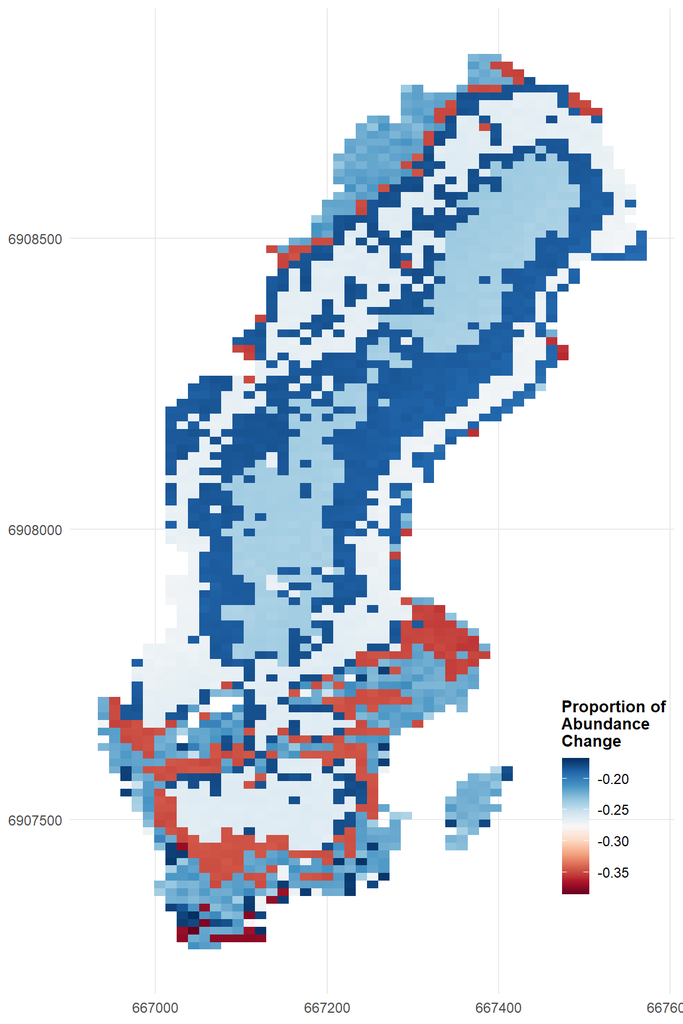

```r
# list for prop abundance change rasters for all sps
prop_abund_change <- list()
# go through each species
for (target_sps in target_species) {
  # import abundance raster after the burn-in for sps
  sps101 <- rast(list.files(path = dirout,
            pattern = paste0(".*101_", target_sps, "_abundance\\.tif"),
            full.names = TRUE))
  # import final abundance raster for sps
  sps125 <- rast(list.files(path = dirout,
                       pattern = paste0(".*125_", target_sps, "_abundance\\.tif"),
                       full.names = TRUE))

  # calculate the prop abundance change raster for each sps
  prop_abund_change[[target_sps]] <- (sps125 - sps101) / sps101
}

# Step 2 - Average across all species to get proportion of abund change for MAMMALS
# stack resampled prop abund change rasters for all sps
all_props_stack <- terra::rast(unlist(prop_abund_change))
# average across all layers (species)
mammals_propAbundChange <- terra::mean(all_props_stack, na.rm = TRUE)
# convert to df
mammals_propAbundChange_df <- as.data.frame(mammals_propAbundChange, xy = TRUE)
library(RColorBrewer)
# Step 3 - Plot mean propotion of abundance change
mammals_abundChange <- ggplot() +
  geom_raster(data = mammals_propAbundChange_df, aes(x = x, y = y, fill = mean)) +
  scale_fill_gradientn(colors = brewer.pal(11, "RdBu"), na.value = "transparent") +
  labs(x = "Latitude", y = "Longitude", fill = "Proportion of\nAbundance\nChange") +
  theme_minimal() +
  theme(legend.title = element_text(size = 10, face = "bold",vjust = 0.9),
        legend.position = c(0.9, 0.2),
        # remove background and line from legend box
        legend.box.background = element_rect(fill = NA, color = NA),
        # remove grid lines
        panel.background = element_blank(),
        panel.grid.minor = element_blank(),
        # remove coordinates and axis labels
        axis.title = element_blank())

# visualise the results
mammals_abundChange
```

# Dispersal change across species

One of the outputs of the metaRange model is a dispersal change raster, which represents the net change in the number of individuals in each grid cell during a given timestep. By averaging dispersal change across all species and timesteps, we can identify key areas of high influx (where individuals are arriving in greater numbers) and high departure (where individuals are leaving the most). The steps bellow explain how we can visualize these results for the mammals in Sweden.

For each species, we:

1. identify and import all the dispersal change rasters for timestep 101 (first step after the burn-in period) and 125 (last timestep)
2. Store the rasters within a list
3. Stack all rasters per species
4. Compute the mean for each cell across all timesteps
5. Store the averaged raster per species in a new list

   Then to get an overview for all mammals,
6. Stack the averaged dispersal change rasters for all species
7. Compute the overall mean dispersal change
8. Finally to visualize the results using `ggplot()` we convert the resulting raster into a dataframe

```r
# list for dispersal change raster for all timesteps & species
dispChange_list <- list()
# list for dispersal change rasters averaged per species
averaged_dispChange_rasters <- list()
# go through each species
for (target_sps in target_species) {

  # Step 1 - Find dispersal change rasters for all species

  dispChange_files <- list.files(path = dirout,
                                # import only raster for timesteps 101 to 125
                                pattern = paste0(".*(10[1-9]|11[0-9]|12[0-5])_", target_sps, "_dispersal_change\\.tif"),
                                full.names = TRUE)
  if (length(dispChange_files) > 0) {
    # read all dispersal change rasters for the species
    dispChange_rasters <- lapply(dispChange_files, rast)
    # store all rasters into a list
    dispChange_list[[target_sps]] <- dispChange_rasters
  } else {
    # print a warning if no rasters are found a target species
    dispChange_list[[target_sps]] <- NULL
    print(paste("No abundance files found for", target_sps))
  }

  # Step 2 - Average rasters per species

  # stack species rasters
  dispChange_stack <- terra::rast(dispChange_list[[target_sps]])
  # calculate the mean across all timesteps (layers)
  averaged_dispChange_raster <- terra::mean(dispChange_stack, na.rm = TRUE)
  # store the averaged raster in a list
  averaged_dispChange_rasters[[target_sps]] <- averaged_dispChange_raster
}

# Step 3 - Average all resampled rasters into one for mammals
dispChange_mammals_stack <- terra::rast(unlist(averaged_dispChange_rasters))
mammals_meanDispChange <- terra::mean(dispChange_mammals_stack, na.rm = TRUE)
# transform into dataframe
mammals_meanDispChange_df <- as.data.frame(mammals_meanDispChange, xy = TRUE)

# Step 4 - Plot mean abundance over time
mammals_dispChange <- ggplot() +
  geom_raster(data = mammals_meanDispChange_df, aes(x = x, y = y, fill = mean)) +
  scale_fill_gradient2(low = "chartreuse3", mid = "white", high = "firebrick3", midpoint = 0, name = "Mean Dispersal\nChange Over\nTime (nº of indiv.)") +
  theme_minimal() +
  labs(x = "Latitude", y = "Longitude", caption = "*Green areas along the map borders are edge effects\nEPSG:3006")
  theme(legend.title = element_text(size = 10, face = "bold", vjust = 0.9),
        legend.position = c(0.9, 0.2),
        # remove background and line from legend box
        legend.box.background = element_rect(fill = NA, color = NA),
        # remove grid lines
        panel.background = element_blank(),
        panel.grid.minor = element_blank(),
        # remove coordinates and axis labels
        axis.title = element_blank())
```

[output not shown]

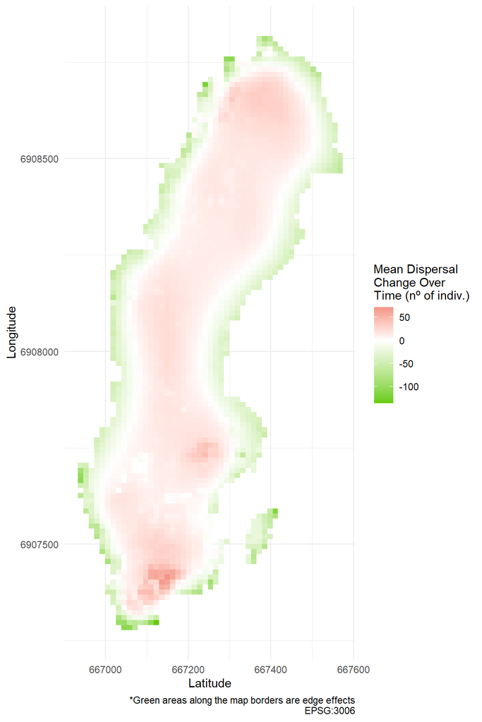

```r
mammals_dispChange
```

# Multispecies model validation

Model validation here relies on a previously set user defined function that compares estimated values from our model simulation with an external data source, which in this case came from Santini et al. 2022.

The `validateModel1.2()` function evaluates the performance of our model abundance estimates. It facilitates a direct comparison between model-predicted densities and independent density estimates, providing insights into the model’s accuracy. The function:

1. prepares the independent density data, filtering it to match the target species and formatting it
2. then it goes through user-specified directories, searching for and reading raster files for species abundance for the specified year. These rasters are then stacked and transformed into a data frame, enabling cell-by-cell analysis. (it also prints a message saying which raster was used for which species) and warns if some are missing.
3. subsequently, the function calculates the mean predicted abundance for each cell, effectively summarizing the model’s output. This information is then joined with the species-specific modeling resolution data, allowing for the calculation of estimated densities. Finally, the function returns a list containing both the processed independent density estimates and the calculated model-predicted densities, facilitating the comparison and validation of the model’s performance.

```r
validateModel1.2 <- function(targetspecies, independentDensity, dirouts, spData, validationYear) {
  # Compares mean density estimated by model per cell with
  # predicted density from independent model extract predicted abundance
  # and join with observed abundance
  # THIS FUNCTION WAS ADAPTED FROM ANDRÉS CODE TO WORK THROUGH MULTIPLE DIRECTORIES (dirouts).

  ## Species density estimates by an INDEPENDENT SOURCE (akin to observed density)
  independentDensity <- independentDensity %>%
    dplyr::filter(Species %in% targetspecies) %>%
    dplyr::select(Species, lw95, lw75, PredMd, up75, up95) %>%
    mutate(
      lw95 = as.numeric(lw95),
      lw75 = as.numeric(lw75),
      PredMd = as.numeric(PredMd), # Predicted population density (individuals/km2)
      up75 = as.numeric(up75),
      up95 = as.numeric(up95)
    ) %>%
    rename(
      species = Species,
      meanDensity = PredMd
    )

  ## Species density estimated by METARANGE from multiple directories
  abundance_files <- list()
  for (target_sps in targetspecies) {
    all_files <- character()
    for (dirout in dirouts) { #Iterate through each directory
      files <- list.files(
        path = dirout,
        pattern = paste0(validationYear, "_", target_sps, "_abundance\\.tif$"),
        full.names = TRUE
      )
      all_files <- c(all_files, files)
    }
    abundance_files[[target_sps]] <- all_files
    if(length(all_files) > 0){
      message(paste("Used rasters for", target_sps, ":", paste(basename(all_files), collapse = ", ")))
    } else {
      warning(paste("No rasters found for", target_sps, "in the given directories."))
    }
  }

  abundance_rasters <- lapply(abundance_files, function(files) {
    lapply(files, terra::rast)
  })

  abundance_stack_list <- lapply(abundance_rasters, function(raster_list){
    if(length(raster_list) > 0){
      terra::rast(unlist(raster_list))
    } else {
      NULL
    }
  })

  # convert raster stack to df
  species_df <- lapply(names(abundance_stack_list), function(sps_name){
    stack <- abundance_stack_list[[sps_name]]
    if(!is.null(stack)){
      lapply(1:terra::nlyr(stack), function(i){
        as.data.frame(stack[[i]], xy = TRUE) %>%
          mutate(species = sps_name) %>%
          rename(abundance = 3)
      }) %>% bind_rows()
    } else {
      NULL
    }
  }) %>% bind_rows()

  # format raster's dataframe for validation
  predicted <- species_df %>%
    dplyr::filter(species %in% targetspecies) %>%
    dplyr::group_by(species, x, y) %>%
    dplyr::summarise(
      meanNInd = mean(abundance, na.rm = TRUE),
      .groups = "drop"
    ) %>%
    as.data.frame()

  spData2 <- spData %>%
    dplyr::select(Species, ModellingRes) %>%
    rename(species = Species) %>%
    mutate(ModellingRes = ifelse(ModellingRes == unique(ModellingRes)[1], unique(ModellingRes)[1], unique(ModellingRes)[1])) %>% #modified to take the first unique value of ModellingRes
    as.data.frame()

  estimatedDensityJoin <- dplyr::inner_join(predicted, spData2, by = "species") %>%
    mutate(estimatedDensity = meanNInd / ModellingRes)

  ## compare observed with predicted density
  result_list <- list(independentDensity, estimatedDensityJoin)
  names(result_list) <- c("independentDensity", "estimatedDensity")
  return(result_list)
}
```

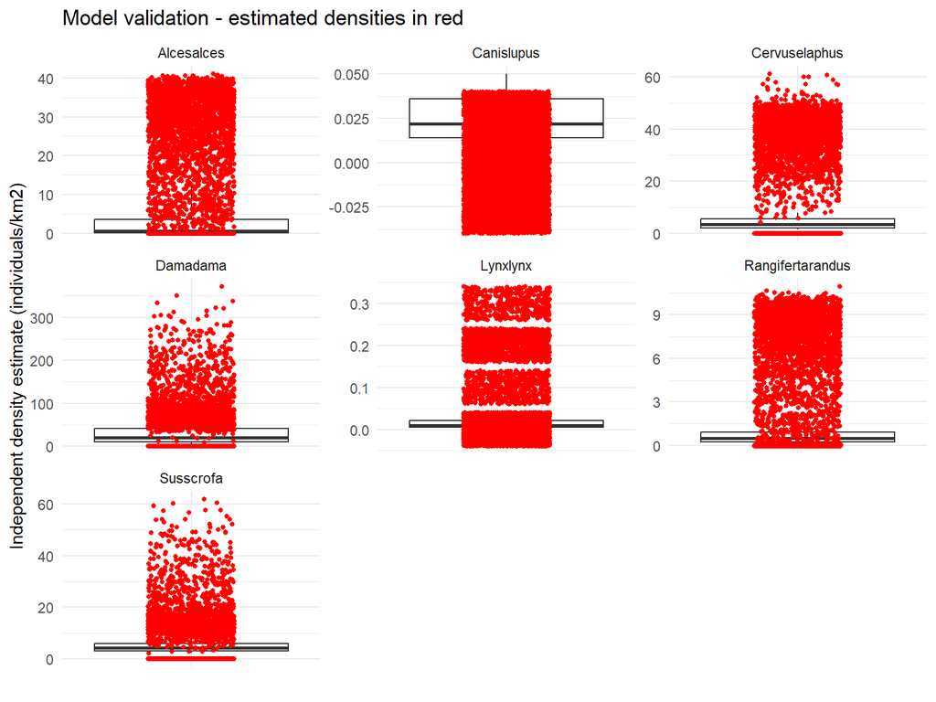

```r
#load external data
# (2) independentDensity
santini2022 <- read_excel("C:/Users/User/OneDrive - Universidade de Lisboa (1)/ANDRE/SRIT_ANDRE/external_data/geb13476-sup-0002-tables1.xls") %>%
  # santini's dataframe has species names with spaces but metaRange does not like spaces
  # remove spaces again
  mutate(Species = str_replace_all(Species, " ", ""))

# (4) spData
spData <- read.csv(file.path(dirinput, "metaRangeSpeciesDataframe.csv"))


# applying the function
validation_lists <- validateModel1.2(targetspecies = target_species,
                       independentDensity = santini2022,
                       dirouts = dirout,
                       spData = spData,
                       validationYear = 101)
# plotting the results
ggplot(validation_lists$independentDensity, aes(x = "", y = meanDensity)) +
  geom_boxplot(aes(ymin = lw95, lower = lw75, middle = meanDensity, upper = up75, ymax = up95), stat = "identity") +
  geom_point(data = validation_lists$estimatedDensity, aes(x = "", y = estimatedDensity), color = "red", position = position_jitter(width = 0.2), size = 1) +
  facet_wrap(~ species, scales = "free_y") +
  ylab("Independent density estimate (individuals/km2)") +
  xlab(" ") +
  ggtitle("Model validation - estimated densities in red") +
  theme_minimal() +
  theme(axis.text.x = element_blank(),
        axis.ticks.x = element_blank())
```